# Predicting Grades

```r
m325 <- read.csv('math325grades_train.csv', header = TRUE, stringsAsFactors = TRUE)

# That's a lot of columns! Let's mutate columns to see its effect on our data
mygrades <- m325 %>%
  mutate(analysis = (Analysis_Stephanie + Analysis_HighSchoolSeniors + Analysis_RecallingWords +
           Analysis_DayCare + Analysis_Chocolate + Analysis_MySimpleLinearRegression +
           Analysis_CarPrices + Analysis_MyLogisticRegression + Analysis_MyChiSquaredTest)/9) %>%
  mutate(analysisnet = case_when(
    analysis == 15 ~ 'yes',
    TRUE ~ 'no'))
```

## Model Searching

```r
#pairs(mygrades, panel=panel.smooth)
```

Several models were searched in order to gather information on what influences the final grade of a student in MATH 325. First, the ‘analysisnet’ column tells us whether a student resubmitted each analysis to get a 15 on each or not. This was found to be significant which is why it is found in the models below.

The assessment quiz final score seemed to show a relationship in the pairs plot. Below is the model for the assessment quiz final score and the analysis net. Each variable in the summary table is considered significant, meaning that each has a p-value of less than 0.05. Continually, at the bottom of the summary table is the AIC at 128.24. This number doesn’t have much value on its own but we can use this to compare to the rest of the models. The lowest AIC will show us which model best fits the data.

```r
# model attempt 1: assessment quiz average score & if they finished all analysis
# AIC: 128.24
myglm <- glm(FinalScore > 89.9 ~ AssessmentQuizzesFinalScore + as.factor(analysisnet), data = mygrades, family = binomial)
summary(myglm)
```

```
##
## Call:
## glm(formula = FinalScore > 89.9 ~ AssessmentQuizzesFinalScore +
##     as.factor(analysisnet), family = binomial, data = mygrades)
##
## Deviance Residuals:
##     Min       1Q   Median       3Q      Max
## -1.9346  -0.8527  -0.4364   1.0085   1.9407
##
## Coefficients:
##                             Estimate Std. Error z value Pr(>|z|)
## (Intercept)                 -3.78546    0.94676  -3.998 6.38e-05 ***
## AssessmentQuizzesFinalScore  0.05541    0.01552   3.569 0.000358 ***
## as.factor(analysisnet)yes    3.62868    1.08346   3.349 0.000811 ***
## ---
## Signif. codes:  0 '***' 0.001 '**' 0.01 '*' 0.05 '.' 0.1 ' ' 1
##
## (Dispersion parameter for binomial family taken to be 1)
##
##     Null deviance: 164.72  on 119  degrees of freedom
## Residual deviance: 122.24  on 117  degrees of freedom
## AIC: 128.24
##
## Number of Fisher Scoring iterations: 5
```

Continually, the class activities final score also seemed to show a relationship. Below is the model for the class activities final score and the analysis net. All the variables are shown to be significant as well. The AIC is 123.64 which we will use to compare to the other models.

```r
# model attempt 3: class activity & analysis completion
# AIC: 123.64
myglm3 <- glm(FinalScore > 89.9 ~ ClassActivitiesFinalScore + analysisnet, data = mygrades, family = binomial)
summary(myglm3)
```

```
##
## Call:
## glm(formula = FinalScore > 89.9 ~ ClassActivitiesFinalScore +
##     analysisnet, family = binomial, data = mygrades)
##
## Deviance Residuals:
##      Min        1Q    Median        3Q       Max
## -2.50531  -1.11970  -0.00915   1.20985   1.88856
##
## Coefficients:
##                           Estimate Std. Error z value Pr(>|z|)
## (Intercept)               -35.0947    14.0876  -2.491   0.0127 *
## ClassActivitiesFinalScore   0.3502     0.1418   2.470   0.0135 *
## analysisnetyes              3.2400     1.0671   3.036   0.0024 **
## ---
## Signif. codes:  0 '***' 0.001 '**' 0.01 '*' 0.05 '.' 0.1 ' ' 1
##
## (Dispersion parameter for binomial family taken to be 1)
##
##     Null deviance: 164.72  on 119  degrees of freedom
## Residual deviance: 117.64  on 117  degrees of freedom
## AIC: 123.64
##
## Number of Fisher Scoring iterations: 7
```

## Final Model

Further variables were also searched such as the assessment quiz completion score which was also shown to be significant, however the AIC was 130 which is above that which is below. Below is the final exam score and the analysis net. The AIC is the 80.92 which is lowest of the searched models meaning that this is the best fit model for the data from the models observed. This will be the model used to predict final grades.

```r
# model attempt 2: Final Exam score & if they completed all of the analysis
# AIC: 80.912
myglm2 <- glm(FinalScore > 89.9 ~ FinalExamFinalScore + analysisnet, data = mygrades, family = binomial)
summary(myglm2)
```

```
##
## Call:
## glm(formula = FinalScore > 89.9 ~ FinalExamFinalScore + analysisnet,
##     family = binomial, data = mygrades)
##
## Deviance Residuals:
##      Min        1Q    Median        3Q       Max
## -1.71861  -0.42059  -0.04658   0.39959   2.47534
##
## Coefficients:
##                     Estimate Std. Error z value Pr(>|z|)
## (Intercept)         -6.82586    1.34762  -5.065 4.08e-07 ***
## FinalExamFinalScore  0.10583    0.02097   5.046 4.50e-07 ***
## analysisnetyes       4.57650    1.26612   3.615 0.000301 ***
## ---
## Signif. codes:  0 '***' 0.001 '**' 0.01 '*' 0.05 '.' 0.1 ' ' 1
##
## (Dispersion parameter for binomial family taken to be 1)
##
##     Null deviance: 164.718  on 119  degrees of freedom
## Residual deviance:  74.912  on 117  degrees of freedom
## AIC: 80.912
##
## Number of Fisher Scoring iterations: 6
```

## Mathematical Model

The logistic regression model can be shown below:

$$P(Y_i = 1|x_i) = \frac{e^{\beta_0+\beta_1 x_1i + \beta_2
x_2i}}{1+e^{\beta_0 + \beta_1 x_i + \beta_2 x_2i}} = \pi_i$$

The observations of i are understood as followed:

$Y_i = 1$ denotes that the student earned an A (or A-) in the class

$Y_i=0$ denotes that the student earned below an A

$x_i$ denotes the final exam score

Further interpretations of the model are as followed:

$e^{b_0}$ is interpreted as the odds that the student is a earns an A in the class given the final exam final score

$e^{b_1}$ is interpreted as the proportional change in the odds that $Y_i = 1$ for every unit increase of the final exam final score ($x_i$), for each additional point on the final exam final score, the students probability of being earning an A (or A-) in the class increases by $e^{b_1}$

$e^{b_2}$ is interpreted as whether the students completed each analysis with a 15 or not

## Model

Below is the multiple logistic regression based on previous data of MATH 325 students. The blue line represents the students who have completed every analysis with a perfect score of 15 and the red line is the rest of the students. Represented at the 1 on the y-axis are those who have earned an A (or A-) in the class. Represented at the 0 on the y-axis are those who have earned less than an A in the class, meaning 89.99 and below. Notice how the blue line increases to the 1 far sooner than the red line does. This shows that those who complete all of their analyses are more likely to get an A in the class than those who do not. The x-axis also shows the final exam score as well. For example, as shown by the graph a student who has completed all of their analyses and get above a 50 on the final exam are far more likely to earn an A in the class than a student who hasn’t completed all of the analyses with the same final exam score.

```r
#pairs(mygrades, panel=panel.smooth)

# Base R plot
b <- coef(myglm2)
palette(c("firebrick", "green"))
#plot(FinalScore > 89.99 ~ FinalExamFinalScore, data = mygrades, col = rgb(.1,.1,.1,.1), cex = 2, pch = 16,
#     ylab = '', xlab = 'Final Exam Score')
#curve(exp(b[1] + b[2]*x)/(1+exp(b[1] + b[2]*x)), add = TRUE, col = palette()[1])
#curve(exp((b[1]+b[3]) + b[2]*x)/(1+exp((b[1]+b[3]) + b[2]*x)), add = TRUE, col = palette()[2])
```

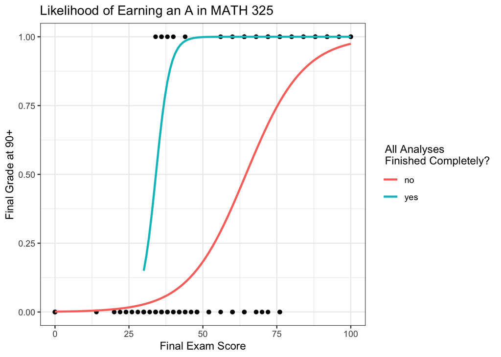

```r
# GGplot
ggplot(mygrades, aes(FinalExamFinalScore, as.numeric(FinalScore>89.99))) +
  geom_point() +
  stat_smooth(aes(color = analysisnet), method = "glm", method.args = list(family = "binomial"), se = FALSE) +
  theme_bw() +
  labs(y = "Final Grade at 90+", x = 'Final Exam Score', color = ' All Analyses \n Finished Completely?', title = 'Likelihood of Earning an A in MATH 325' )
```

# Interpretation of the Model

Lastly, a goodness of fit test will be run to verify if the model is a good fit for the data:

$$H_0: \text{The logistic regression is a good fit for the data}$$

$$H_a: \text{The logistic regression is not a good fit for the data}$$

```r
pander(hoslem.test(myglm2$y, myglm2$fitted.values, g= 10))
```

Hosmer and Lemeshow goodness of fit (GOF) test: `myglm2$y, myglm2$fitted.values`

| Test statistic | df | P value |
| --- | --- | --- |
| 9.083 | 8 | 0.3353 |

Since the p-value is 0.3353 which is higher than the significance level of 0.05, we then fail to reject the null. In other words, the logistic regression is a good fit for the data.

## Model Validation

```r
# let's validate our model in logistic regression!
set.seed(121)
keep <- sample(1:nrow(mygrades),80)

mytrain <- mygrades[keep, ]
mytest <- mygrades[-keep,]

myglm2 <- glm(FinalScore > 89.9 ~ FinalExamFinalScore + analysisnet, data = mytrain, family = binomial)

myprediction <- predict(myglm2, mytrain, type = 'response')

mypredictions <- ifelse(myprediction > 0.5, 1, 0)

pander(table(mypredictions, mytrain$FinalScore>90))
```

|  | FALSE | TRUE |
| --- | --- | --- |
| **0** | 35 | 2 |
| **1** | 5 | 38 |

```r
# PCC Percent Correctly Classified
# Precision, Accuracy,
# (correct + correct)/(totalcorrect + totalcorrect)
# 0.88 or whatever it is

mytest$FinalGrade <- ifelse(predict(myglm2, mytest, type="response") > 0.9, "A", "Other")

write.csv(mytest, "Test.csv", row.names=FALSE)
```